# Homework #2

Grant Ruedy; GrantRuedy

## R commands

1. Today’s temperature has a high of 15 and a low of -10 degree fahrenheit. Find the corresponding degress in celsius and storage it in a (single) vector named `cel`. Print the variable.

```r
temps <- c(15,-10)
cel <-((temps)-32)*(5/9)
cel
```

```
## [1]  -9.444444 -23.333333
```

2. Create a vector of length 200. The odd entries should be 1 and even entries should be 0. Storage the created in a variable named `vec200` and print.

```r
vec200 <- rep(c(1,0),100)
vec200
```

```
##   [1] 1 0 1 0 1 0 1 0 1 0 1 0 1 0 1 0 1 0 1 0 1 0 1 0 1 0 1 0 1 0 1 0 1 0 1
##  [36] 0 1 0 1 0 1 0 1 0 1 0 1 0 1 0 1 0 1 0 1 0 1 0 1 0 1 0 1 0 1 0 1 0 1 0
##  [71] 1 0 1 0 1 0 1 0 1 0 1 0 1 0 1 0 1 0 1 0 1 0 1 0 1 0 1 0 1 0 1 0 1 0 1
## [106] 0 1 0 1 0 1 0 1 0 1 0 1 0 1 0 1 0 1 0 1 0 1 0 1 0 1 0 1 0 1 0 1 0 1 0
## [141] 1 0 1 0 1 0 1 0 1 0 1 0 1 0 1 0 1 0 1 0 1 0 1 0 1 0 1 0 1 0 1 0 1 0 1
## [176] 0 1 0 1 0 1 0 1 0 1 0 1 0 1 0 1 0 1 0 1 0 1 0 1 0
```

3. How many perfect squares are there between 1 and 1001? Storage the answer in a variable named `numPerfect` and print. You may want to look at `?round`.

```r
numPerfect <-floor(sqrt(1001)) - ceiling(sqrt(1)) + 1
numPerfect
```

```
## [1] 31
```

## Cars and mileage

1. What are the 3 most fuel-efficient models in terms of highway mileage? Storage the data frame (with 3 rows) containing all information of these three cars in a variable named `top3` and print.

```r
library(ggplot2)

newdata <- mpg[order(-mpg$hwy),]
top3 <- head(newdata,3)
top3
```

```
## # A tibble: 3 x 11
##   manufacturer model displ  year   cyl trans drv     cty   hwy fl    class
##   <chr>        <chr> <dbl> <int> <int> <chr> <chr> <int> <int> <chr> <chr>
## 1 volkswagen   jetta   1.9  1999     4 manu… f        33    44 d     comp…
## 2 volkswagen   new …   1.9  1999     4 manu… f        35    44 d     subc…
## 3 volkswagen   new …   1.9  1999     4 auto… f        29    41 d     subc…
```

The top 3 most fuel efficient models for highway mileage are the Volkswagen jetta,  
new beetle, and new beetle again. The data is sorted by the ‘hwy’ column in  
descending order, then the top 3 are sown using the head function.

2. How many different compact models are included in this dataset? Storage the answer in a variable named `numCompact` and print.

```r
mpg_compact <- mpg[mpg$class== 'compact',]
numCompact <-length(unique(mpg_compact$model))
numCompact
```

```
## [1] 8
```

There are 8 different compact models in this data set. The data is sorted to where  
the class is equal to ‘compact’ then the length of that data using the unique  
feature for the ‘model’ variable is stored and printed.

3. Create a scatterplot of `hwy` and `cty` and describe the relationship. Why are there so few points visible?

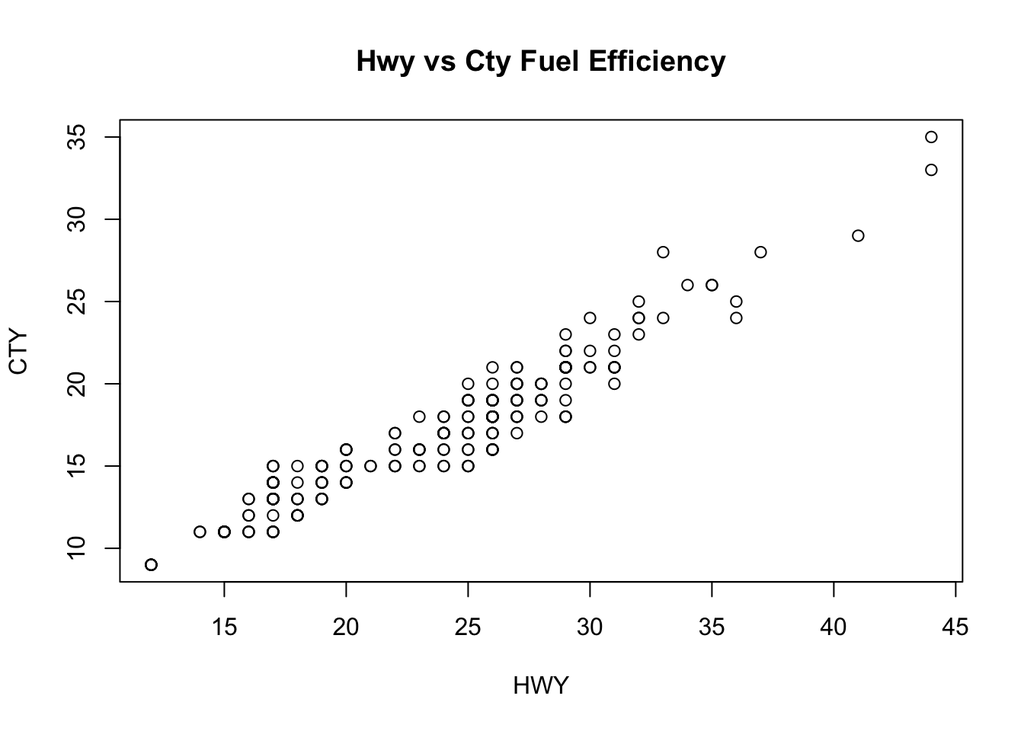

```r
library(ggplot2)
plot(mpg$hwy, mpg$cty, xlab='HWY',ylab='CTY',main='Hwy vs Cty Fuel Efficiency')
```

To plot ‘hwy’ and ‘cty’ against each other, the plot function is used and the  
correct columns from the data set is specified. There appears to be a moderately  
strong, positive linear relationship between mileage on the highway and in the city.  
So few points are visible because a lot of them overlap since the cars have the same mileage for hwy and cty.

4. Are cars in 2008 more fuel efficient than cars in 1999? Use graphs *and* summary statistics to answer this question.

```r
dat2008 <- mpg[mpg$year== 2008,]
dat1999 <- mpg[mpg$year== 1999,]

hwy2008 <- dat2008$hwy
cty2008 <- dat2008$cty

hwy1999 <- dat1999$hwy
cty1999 <- dat1999$cty

summary(hwy1999)
```

```
##    Min. 1st Qu.  Median    Mean 3rd Qu.    Max.
##   15.00   17.00   25.00   23.43   26.00   44.00
```

```r
summary(cty1999)
```

```
##    Min. 1st Qu.  Median    Mean 3rd Qu.    Max.
##   11.00   14.00   17.00   17.02   19.00   35.00
```

```r
summary(hwy2008)
```

```
##    Min. 1st Qu.  Median    Mean 3rd Qu.    Max.
##   12.00   18.00   24.00   23.45   28.00   37.00
```

```r
summary(cty2008)
```

```
##    Min. 1st Qu.  Median    Mean 3rd Qu.    Max.
##     9.0    13.0    17.0    16.7    20.0    28.0
```

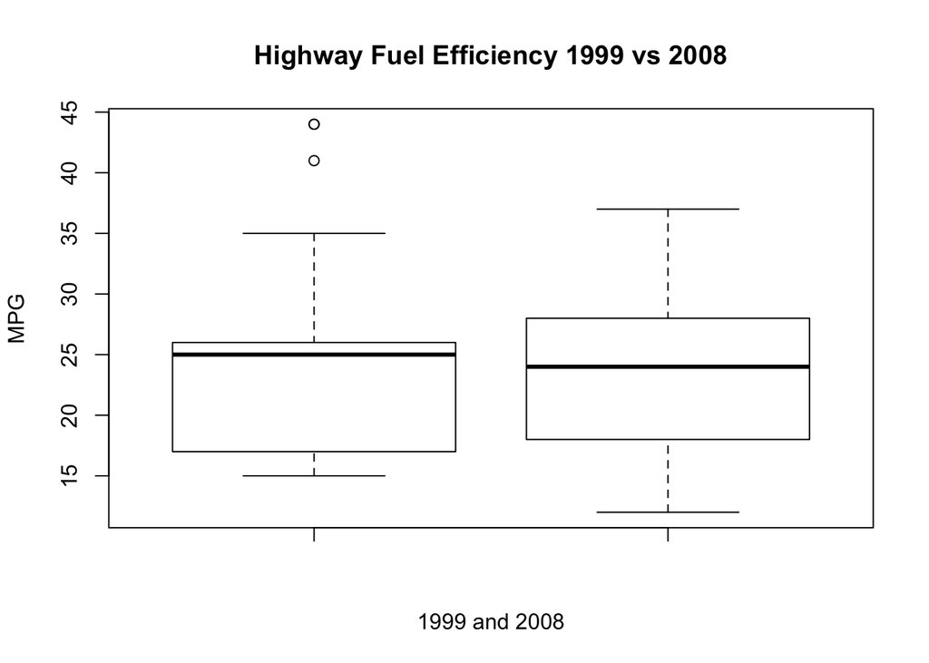

```r
boxplot(hwy1999, hwy2008, xlab='1999 and 2008',ylab='MPG',main='Highway Fuel Efficiency 1999 vs 2008')
```

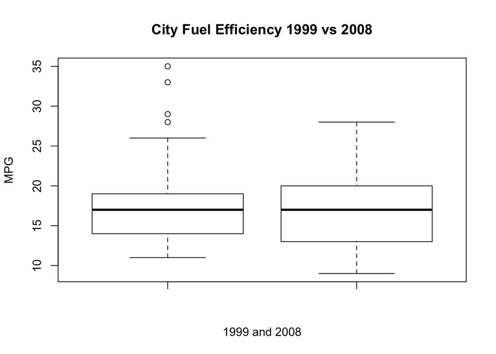

```r
boxplot(cty1999, cty2008, xlab='1999 and 2008',ylab='MPG',main='City Fuel Efficiency 1999 vs 2008')
```

To find out if 2008 cars were more fuel efficient than 1999 cars, I first subsetted  
the data to where the year was equal to 1999 or 2008. Then for each year, I sorted it  
to just the ‘cty’ and ‘hwy’ column, which measures the mileage on the highway or in  
the city. The, using the summary function on these data sets, it is easy to compare  
the average between years. The boxplot function also allows for a graphical  
representation of the mileage comparing it from 1999 to 2008. Looking at summary  
statisitcs, 2008 cars are not more fuel efficient than 1999 cars because the mean and  
median are within one for each year. In fact, the maximum value actually goes down  
from 1999 to 2008. Looking at the boxplot for each kind of driving, there is no  
noticable increase in fuel efficiency from 1999 to 2008, as the boxes are about even.